# Exploratory Analysis of COVID-19 in New Zealand

### Introduction

This project provides an exploratory analysis of the data relating to confirmed cases of COVID-19 in New Zealand as at 29th March, 2020. At this point, there were 552 confirmed cases.

The main motivation for this work is to support researchers and anyone who may be interested in understanding key trends and to ask more and better questions that may support research and eventual elimination of COVID-19.

The data file has been sourced from [Ministry of Health](https://www.health.govt.nz/our-work/diseases-and-conditions/covid-19-novel-coronavirus/covid-19-current-situation/covid-19-current-cases/covid-19-current-cases-details)

To illustrate by example, below are the details of the top five rows of the data.

|  | Report.Date | Sex | Age.Group | DHB | Overseas | Last.country.before.NZ | Flight.no | Departure.date | Arrival.date |
| --- | --- | --- | --- | --- | --- | --- | --- | --- | --- |
| 1 | 2020-03-29 | Male | 50 to 59 | Auckland | Yes |  |  |  | 22/03/2020 |
| 2 | 2020-03-29 | Female | 50 to 59 | Auckland | Yes |  |  |  | 24/03/2020 |
| 3 | 2020-03-29 | Male | 40 to 49 | Auckland |  |  |  |  |  |
| 4 | 2020-03-29 |  | 20 to 29 | Auckland |  |  |  |  |  |
| 5 | 2020-03-29 | Female | 20 to 29 | Auckland |  |  |  |  |  |

The purpose of this analysis was to answer the following key questions:

1. What is the daily trend for confirmed cases?
2. Exploratory Analysis of key variables and their interactions.
3. Are there any cluster of variables?

To answer these questions, the following trend analysis was conducted:

1. Origin of Virus
2. Distribution by age
3. Distribution by gender
4. Distribution by Location
5. Location versus age, gender and origin
6. Distribution by age vs gender
7. Overseas vs sex and age
8. Distribution by country last visited
9. Last Country versus age, gender and region
10. Distribution by Duration since departure
11. Multiple Correspndence Analysis
12. Heirarchical Clustering
13. Hierarchical Clustering on Principal Components
14. K-Modes Clustering
15. Factor Analysis

This report is divided according to the three research questions followed by a conclusion.

### 1. Daily Trend Analysis

The plot below shows the trend for the number of people confirmed to have COVID-19 on a given day. The x axis represents the date and the y axis represents the number confirmed cases.

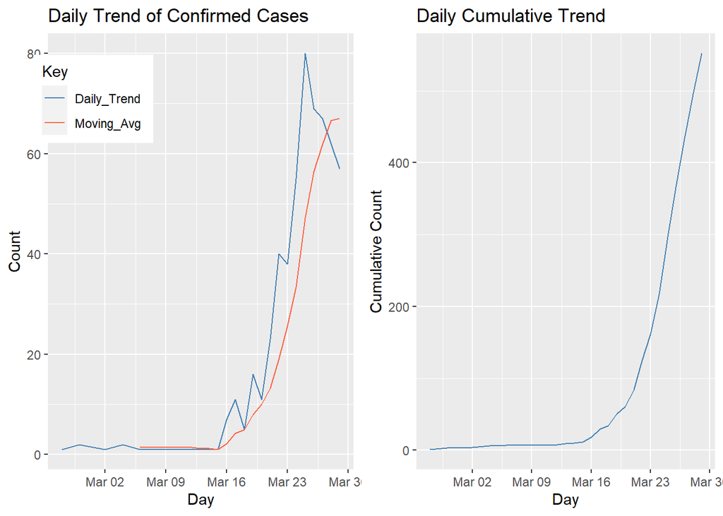

The graph above shows that the number of confirmed cases has been increasing steeply since the 16th of March.

### 2. Exploratory Analysis of key variables.

#### 2.1. Origin of Virus

Within the dataset, there are three groups of people.

1. Cases who reported travelling overseas
2. Cases who did not travel overseas
3. Cases who did not report any travel information

The following analysis compares the daily trend for each of these groups.

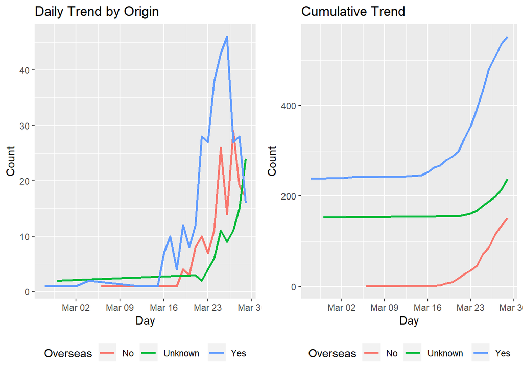

These results show that majority of the cases have travelled overseas and that cumulatively, the rate at which these cases are being confirmed is increasing exponentially. The curve is showing signs of leveling due to travel restrictions globally.

The number of patients who have not traveled overseas is also showing what appears to be an exponential increase since around the 20th of March. In the event of a community outbreak, this graph should overtake the line for cases who traveled overseas.

#### 2.2. Distribution by age

The following bar chart shows the distribution of the confirmed cases by age

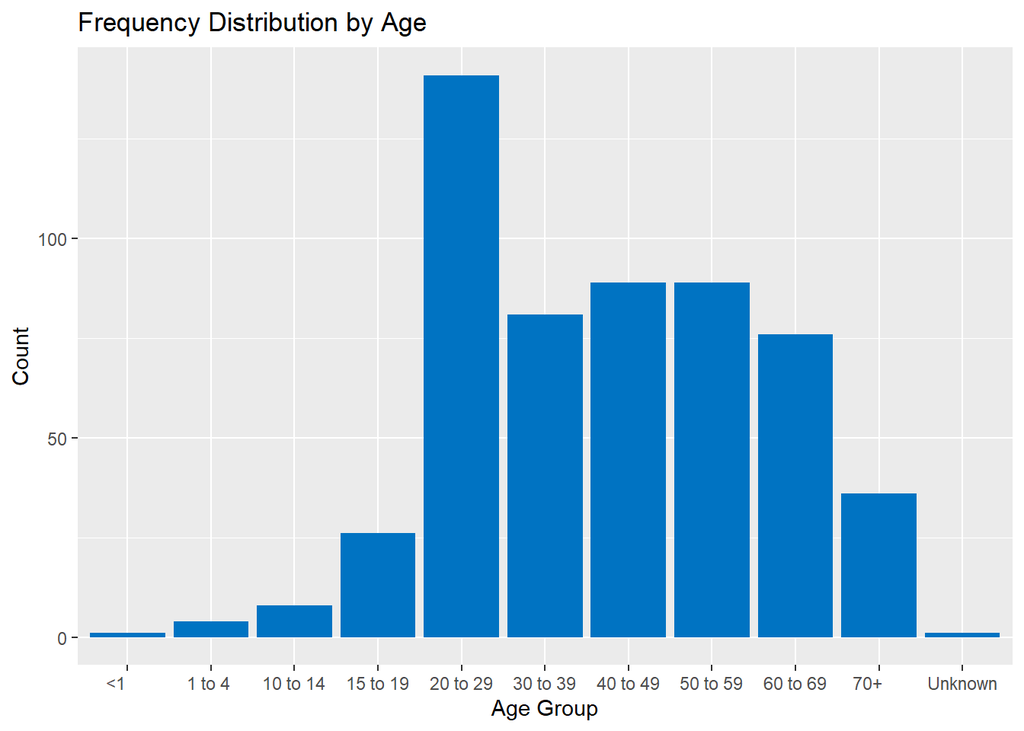

The distribution shows that:

- a large proportion of cases are between the ages of 20 and 29.
- over 20% of cases are older than 60 years.
- less than 10% of patience are below the age of 20.

The table below shows the percentage of cases in each age group.

| Age | Percentage |
| --- | --- |
| 20 to 29 | 25.5 % |
| 40 to 49 | 16.1 % |
| 50 to 59 | 16.1 % |
| 30 to 39 | 14.7 % |
| 60 to 69 | 13.8 % |
| 70+ | 6.5 % |
| 15 to 19 | 4.7 % |
| 10 to 14 | 1.4 % |
| 1 to 4 | 0.7 % |
| <1 | 0.2 % |
| Unknown | 0.2 % |

The following graphs show the distribution and cumulative distribution of the top six case groups over time.

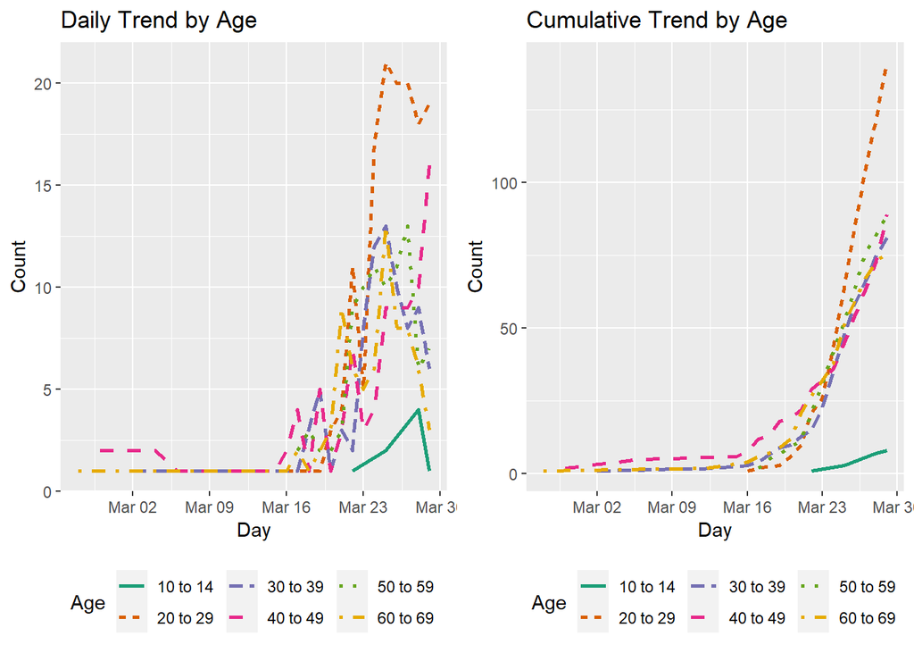

Again, cases in the 20 to 29 year group have shown the sharpest increase followed by cases between the ages of 30 and 60.

$~$

#### 2.2. Distribution by gender

[figure not shown]

The distribution shows that there is a fairly even representation of males and females with females outnumbering males slightly.

| Gender | Percentage |
| --- | --- |
|  | 0.9 % |
| Female | 52.9 % |
| Male | 46.2 % |

The following graphs show the distribution and cumulative distribution of these cases over time.

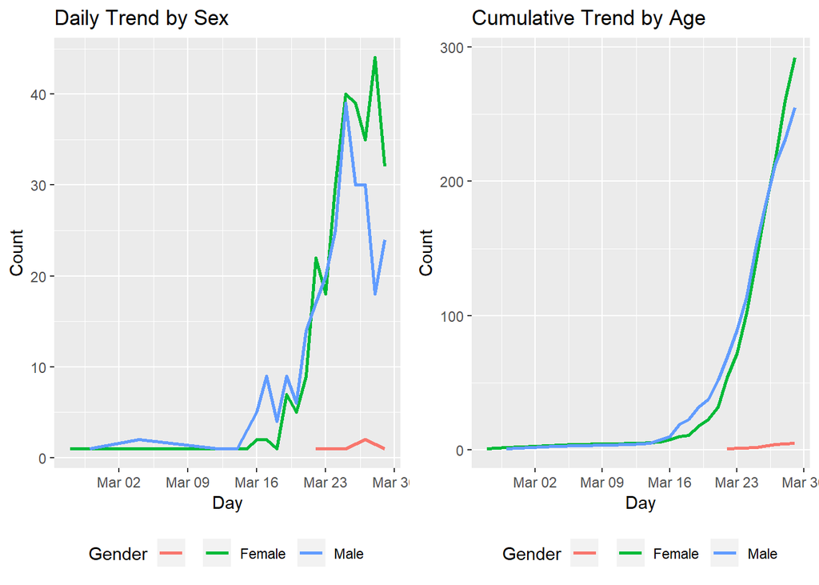

These charts show a fairly even trend although Females appear to have a slightly steeper curve.

$~$

#### 2.3. Distribution by Location

The following distribution relates to the District Health Board where these cases were identified.

[figure not shown]

Auckland has the largest immigrant population which could possibly explain the high number of cases.

The table below shows the percentage of cases in each region.

|  | Age | Percentage |
| --- | --- | --- |
| 1 | Auckland | 15.2 % |
| 2 | Southern | 14.9 % |
| 3 | Waikato | 13.4 % |
| 4 | Waitemata | 12.9 % |
| 5 | Capital and Coast | 9.2 % |
| 6 | Canterbury | 8 % |
| 7 | Counties Manukau | 6.7 % |
| 8 | Nelson Marlborough | 3.4 % |
| 9 | Hawke’s Bay | 2.2 % |
| 10 | Hutt Valley | 2.2 % |
| 11 | Bay of Plenty | 1.8 % |
| 12 | MidCentral | 1.8 % |
| 13 | Taranaki | 1.8 % |
| 14 | Lakes | 1.6 % |
| 15 | Northland | 1.4 % |
| 16 | South Canterbury | 1.3 % |
| 17 | Wairarapa | 0.9 % |
| 18 | West Coast | 0.5 % |
| 19 | Whanganui | 0.5 % |
| 20 | Tairawhiti | 0.2 % |

The following graphs show the distribution and cumulative distribution of the top six districts over time.

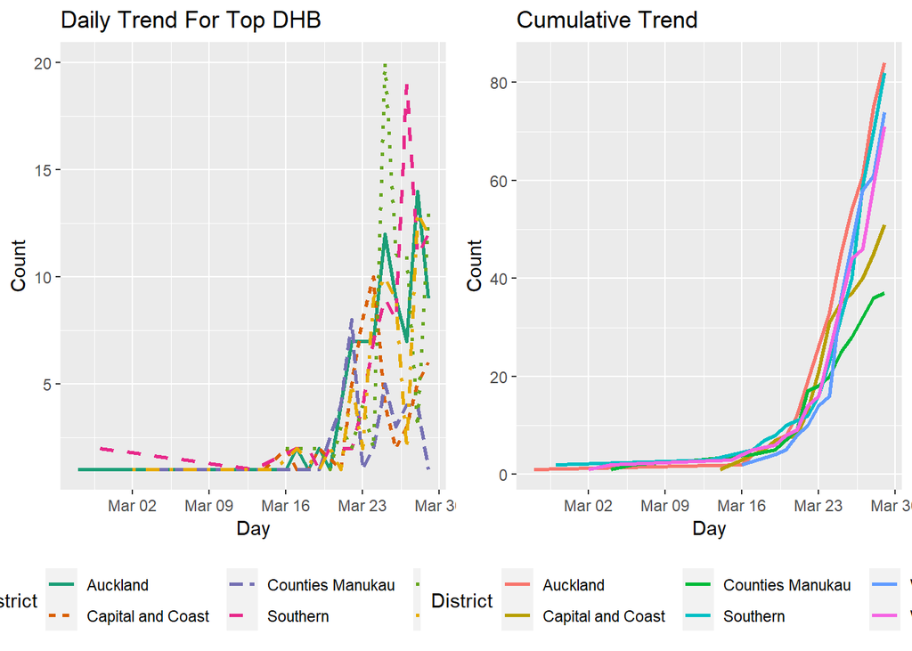

The map below shows the distribution of cases by the geographic location.

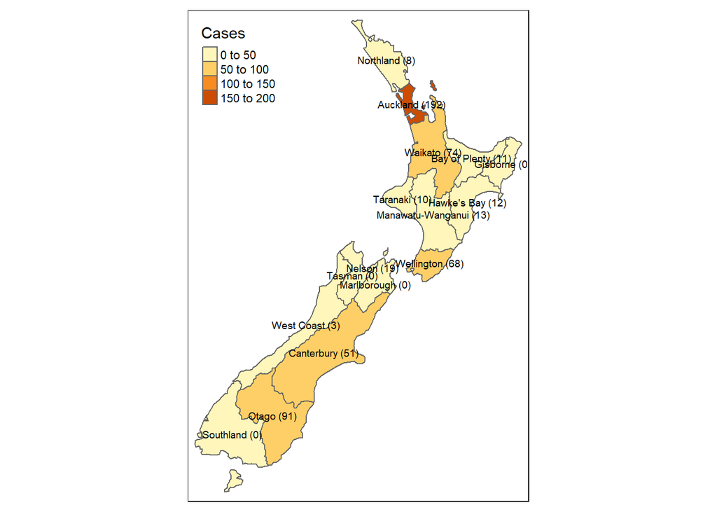

#### 2.4. Location versus age, gender and origin

**2.4.1. Gender Distribution by Region**

| Region | Female | Male | Unknown | Percentage Females |
| --- | --- | --- | --- | --- |
| Auckland | 107 | 83 | 2 | 55.7 |
| Bay of Plenty | 6 | 5 | 0 | 54.5 |
| Canterbury | 30 | 20 | 1 | 58.8 |
| Wellington | 32 | 36 | 0 | 47.1 |
| Hawke’s Bay | 6 | 6 | 0 | 50 |
| Otago | 46 | 45 | 0 | 50.5 |
| Manawatu-Wanganui | 7 | 5 | 1 | 53.8 |
| Nelson | 6 | 13 | 0 | 31.6 |
| Northland | 6 | 2 | 0 | 75 |
| Taranaki | 4 | 5 | 1 | 40 |
| Waikato | 41 | 33 | 0 | 55.4 |
| West Coast | 1 | 2 | 0 | 33.3 |

**2.4.2. Age Distribution by Region**

The following heat map shows the number of cases in each region by the age distribution. The results show that Auckland and Otago have the largest number of cases who are between 20 and 29 years old.

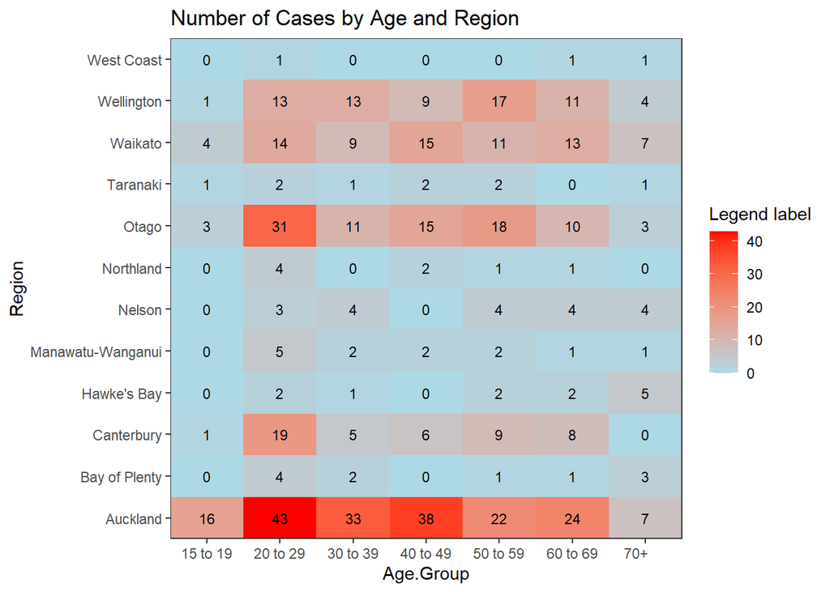

**2.4.3. Origin Distribution by Region**

The following table shows the number of cases in each region and their origins.

| Region | Overseas Yes | Overseas No | Percentage Overseas |
| --- | --- | --- | --- |
| Auckland | 105 | 51 | 67.3 % |
| Bay of Plenty | 9 | 2 | 81.8 % |
| Canterbury | 35 | 14 | 71.4 % |
| Wellington | 51 | 16 | 76.1 % |
| Hawke’s Bay | 9 | 3 | 75 % |
| Otago | 37 | 37 | 50 % |
| Manawatu-Wanganui | 10 | 3 | 76.9 % |
| Nelson | 12 | 4 | 75 % |
| Northland | 5 | 0 | 100 % |
| Taranaki | 9 | 1 | 90 % |
| Waikato | 31 | 18 | 63.3 % |
| West Coast | 1 | 2 | 33.3 % |

$~$

#### 2.5. Distribution by age vs gender

The heat map below shows the number of cases in each age group and their gender. The results show that females between 20 to 29 years make up the highest group and that females make up a large proportion of cases up to the age of 40. Conversely, males make up the larger proportion of cases over the age 40.

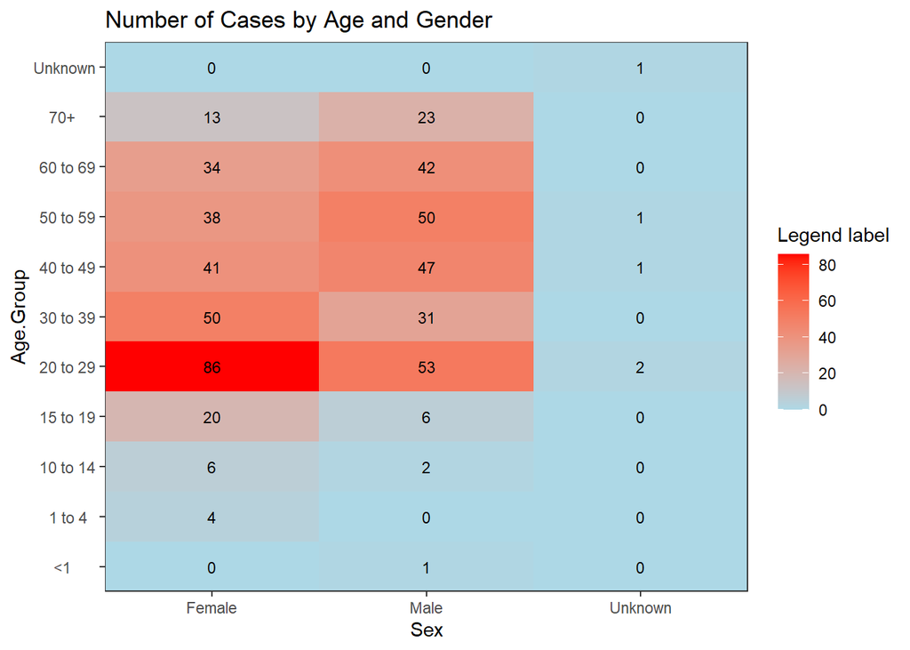

$~$

#### 2.6. Overseas vs sex and age

**2.6.1. Overseas vs Sex**

The following table shows the gender distribution of cases against their origin.

| Sex | Overseas Yes | Overseas No | Percentage Overseas |
| --- | --- | --- | --- |
| Female | 148 | 87 | 50.7 % |
| Male | 163 | 63 | 63.9 % |
| Unknown | 3 | 1 | 60 % |
| Total | 314 | 151 | 56.9 % |

**2.6.2. Percentage Overseas Trend**

The following graph shows the daily trend of percentage of cases that originated overseas and locally.

The green line is the cumulative percentage of cases that originated overseas. The results indicate that a large proportion of cases reported in the earlier period originated overseas however the trend peaked around the 16th of March with a cumulative percentage of approximately 85%. The downward trend since then may be indicative of a growing trend in community transmission.

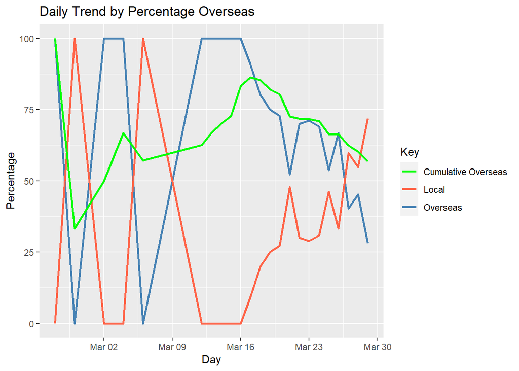

**2.6.3. Overseas vs Age**

The following table shows the breakdown of cases that originated overseas by age group.

| Age | Overseas Yes | Overseas No | Overseas Unknown | Percentage Overseas |
| --- | --- | --- | --- | --- |
| <1 | 0 | 1 | 0 | 0 % |
| 1 to 4 | 2 | 0 | 2 | 50 % |
| 10 to 14 | 0 | 6 | 2 | 0 % |
| 15 to 19 | 8 | 13 | 5 | 30.8 % |
| 20 to 29 | 97 | 21 | 23 | 68.8 % |
| 30 to 39 | 45 | 22 | 14 | 55.6 % |
| 40 to 49 | 45 | 25 | 19 | 50.6 % |
| 50 to 59 | 48 | 26 | 15 | 53.9 % |
| 60 to 69 | 46 | 27 | 3 | 60.5 % |
| 70+ | 22 | 10 | 4 | 61.1 % |
| Unknown | 1 | 0 | 0 | 100 % |
| Total | 314 | 151 | 87 | 56.9 % |

$~$

#### 2.7. Distribution by country last visited

Within that dataset, there is a variable names *Last.country.before.NZ*. This most likely represents the country where a person last boarded their flight to enter New Zealand.

The following table provides the list of all countries and the number of cases.

|  | Country | Cases | Percentage | Cumulative Percentage |
| --- | --- | --- | --- | --- |
| 1 | United States of America | 72 | 23.5 % | 23.5 % |
| 2 | Australia | 42 | 13.7 % | 37.2 % |
| 3 | United Kingdom | 34 | 11.1 % | 48.3 % |
| 4 | United Arab Emirates | 31 | 10.1 % | 58.4 % |
| 5 | Unknown | 30 | 9.8 % | 68.2 % |
| 6 | Singapore | 15 | 4.9 % | 73.1 % |
| 7 | Qatar | 14 | 4.6 % | 77.7 % |
| 8 | France | 7 | 2.3 % | 80 % |
| 9 | Indonesia | 6 | 2 % | 82 % |
| 10 | Switzerland | 6 | 2 % | 84 % |
| 11 | Canada | 5 | 1.6 % | 85.6 % |
| 12 | England | 5 | 1.6 % | 87.2 % |
| 13 | Argentina | 4 | 1.3 % | 88.5 % |
| 14 | Egypt | 3 | 1 % | 89.5 % |
| 15 | Germany | 3 | 1 % | 90.5 % |
| 16 | Ireland | 3 | 1 % | 91.5 % |
| 17 | Spain | 3 | 1 % | 92.5 % |
| 18 | Thailand | 3 | 1 % | 93.5 % |
| 19 | Cambodia | 2 | 0.7 % | 94.2 % |
| 20 | Malaysia | 2 | 0.7 % | 94.9 % |
| 21 | Philippines | 2 | 0.7 % | 95.6 % |
| 22 | Austria | 1 | 0.3 % | 95.9 % |
| 23 | Belgium | 1 | 0.3 % | 96.2 % |
| 24 | Greece | 1 | 0.3 % | 96.5 % |
| 25 | India | 1 | 0.3 % | 96.8 % |
| 26 | Iran | 1 | 0.3 % | 97.1 % |
| 27 | Italy | 1 | 0.3 % | 97.4 % |
| 28 | Japan | 1 | 0.3 % | 97.7 % |
| 29 | Middle East | 1 | 0.3 % | 98 % |
| 30 | Netherlands | 1 | 0.3 % | 98.3 % |
| 31 | Northern America | 1 | 0.3 % | 98.6 % |
| 32 | Portugal | 1 | 0.3 % | 98.9 % |
| 33 | Saudi Arabia | 1 | 0.3 % | 99.2 % |
| 34 | Scotland | 1 | 0.3 % | 99.5 % |
| 35 | Viet Nam | 1 | 0.3 % | 99.8 % |
| 36 | Zimbabwe | 1 | 0.3 % | 100.1 % |

The top 6 countries account for 73.1% of the cases. The following results are based on these countries.

The following graphs show the distribution and cumulative distribution of the origins over time.

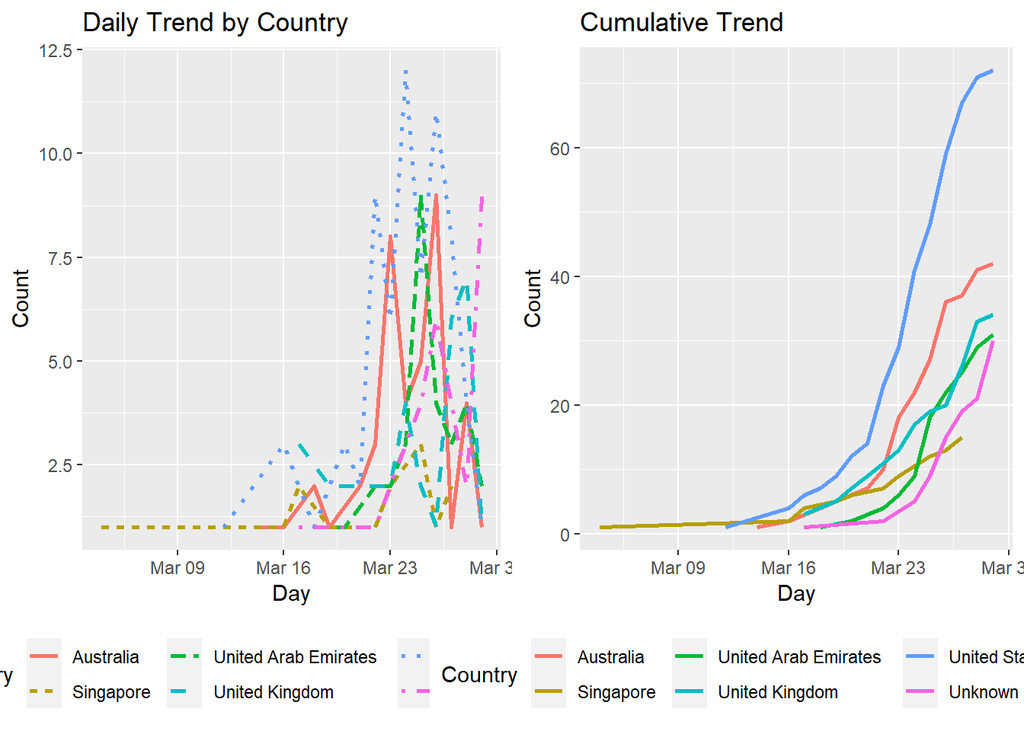

These results show clearly that the highest number of cases arrived into New Zealand from the United States of America and Australia.

$~$

#### 2.8. Last Country versus age, gender and region

**2.8.1. Gender Distribution by Country**

| Country | Female | Male | Unknown | Percentage Females |
| --- | --- | --- | --- | --- |
| United Arab Emirates | 19 | 12 | 0 | 61.3 |
| United Kingdom | 20 | 13 | 1 | 58.8 |
| Australia | 20 | 22 | 0 | 47.6 |
| Unknown | 12 | 16 | 2 | 40 |
| United States of America | 27 | 45 | 0 | 37.5 |
| Singapore | 5 | 10 | 0 | 33.3 |

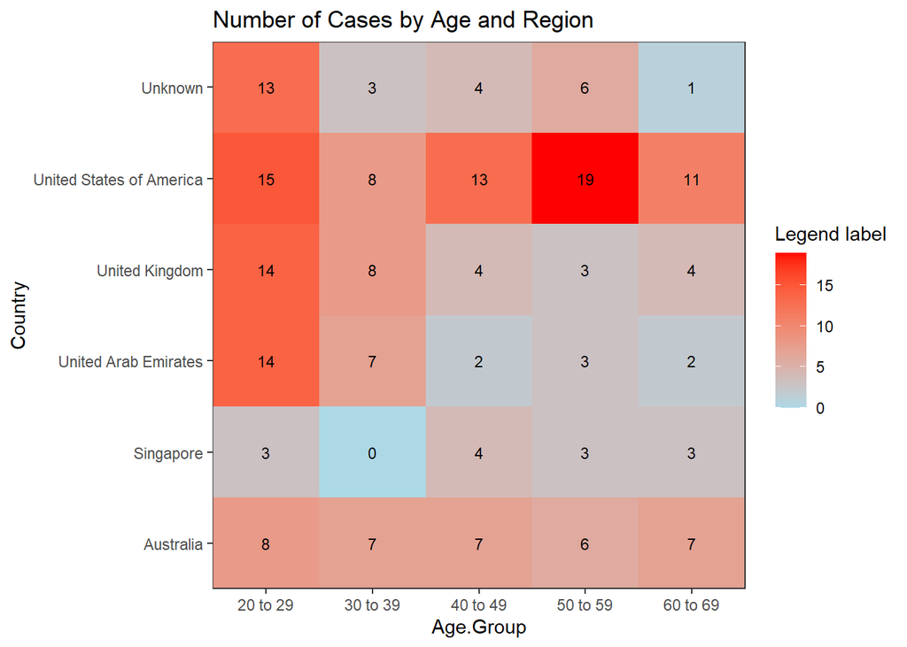

**2.8.3. Last Country vs Region**

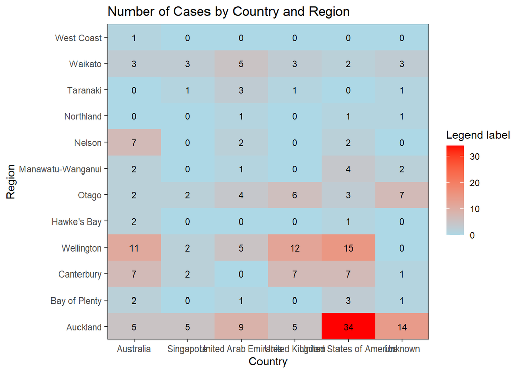

$~$

#### 2.9. Distribution by Duration since departure

For cases that arrived from overseas, duration is defined as the number of days between the date reported and their date of arrival into New Zealand.

Below is the descriptive analysis of this data.

|  | vars | n | mean | sd | median | trimmed | mad | min | max | range | skew | kurtosis | se |
| --- | --- | --- | --- | --- | --- | --- | --- | --- | --- | --- | --- | --- | --- |
| X1 | 1 | 294 | 5.7 | 3.4 | 5 | 5.4 | 3 | 0 | 21 | 21 | 1.2 | 2.4 | 0.2 |

The table below shows average duration by country.

| Country | Average_Duration | Count |
| --- | --- | --- |
| Philippines | 19 | 2 |
| Viet Nam | 11 | 1 |
| Zimbabwe | 11 | 1 |
| Iran | 10 | 1 |
| Northern America | 10 | 1 |
| Cambodia | 9 | 2 |
| India | 9 | 1 |
| Greece | 8 | 1 |
| Ireland | 8 | 2 |
| Japan | 7 | 1 |
| Portugal | 7 | 1 |
| Unknown | 7 | 21 |
| Germany | 7 | 3 |
| Egypt | 6 | 3 |
| France | 6 | 7 |
| Argentina | 6 | 4 |
| Belgium | 6 | 1 |
| Netherlands | 6 | 1 |
| United Arab Emirates | 6 | 30 |
| Australia | 6 | 42 |
| Qatar | 6 | 14 |
| Singapore | 5 | 13 |
| United Kingdom | 5 | 31 |
| Canada | 5 | 5 |
| United States of America | 5 | 70 |
| Austria | 5 | 1 |
| Italy | 5 | 1 |
| Malaysia | 5 | 2 |
| Spain | 5 | 3 |
| Thailand | 5 | 3 |
| Indonesia | 4 | 5 |
| Switzerland | 4 | 6 |
| Middle East | 4 | 1 |
| New Zealand | 3 | 7 |
| England | 3 | 4 |
| Saudi Arabia | 2 | 1 |
| Scotland | 2 | 1 |

The table below shows the average duration by sex. There is no major difference between the two groups.

| Sex | Average Duration |
| --- | --- |
| Female | 5 |
| Male | 6 |
| Unknown | 7 |

The table below shows the average duration by age group. There are no major difference between the groups.

| Age Group | Average Duration |
| --- | --- |
| 20 to 29 | 5 |
| 30 to 39 | 6 |
| 40 to 49 | 6 |
| 50 to 59 | 6 |
| 60 to 69 | 6 |
| 70+ | 6 |

The table below shows the heat map of average duration by sex vs country last visited.

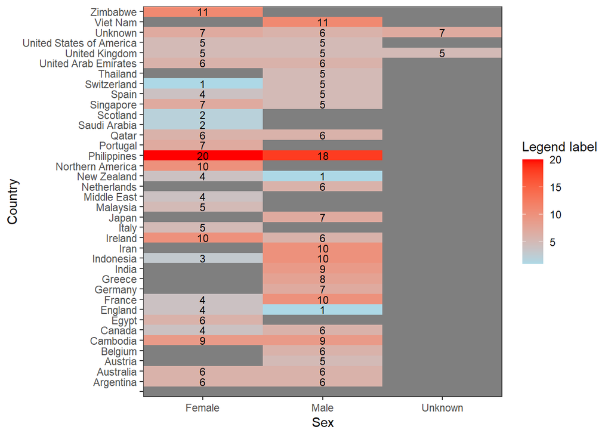

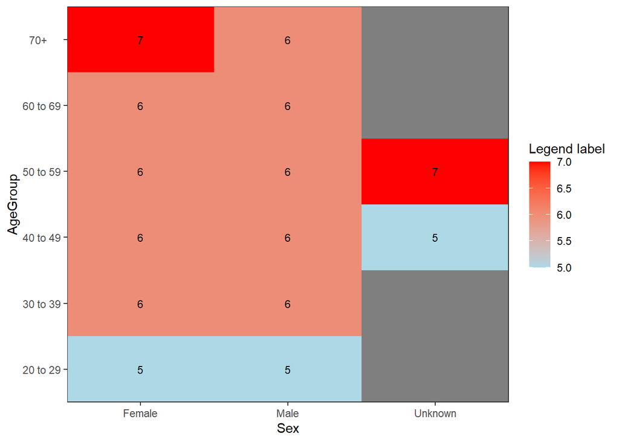

It is difficult to ascertain the reasons behind some of the results above without making further enquiries from the Ministry of Health itself.

$~$

### 3. Multivariate Analysis

The results so far have related to some of the key variables and their interaction with some of the other variables.

In this section, we aim to explore the interaction of all the variables within the multi-dimensional space to determine if there are any other insights within the data set.

$~$

#### 3.1. Multiple Correspndence Analysis

The Multiple correspondence analysis (MCA) is primarily used for summarising and visualising data with more than two categorical variables. It is a generalised form of principal component analysis for dimensionality reduction when the variables to be analyzed are categorical instead of quantitative.

The goal of MCA is to identify:

1. A group of individuals with similar profile in their answers to the questions
2. The associations between variable categories

The scree plot below shows the percentages of inertia explained by each MCA dimension

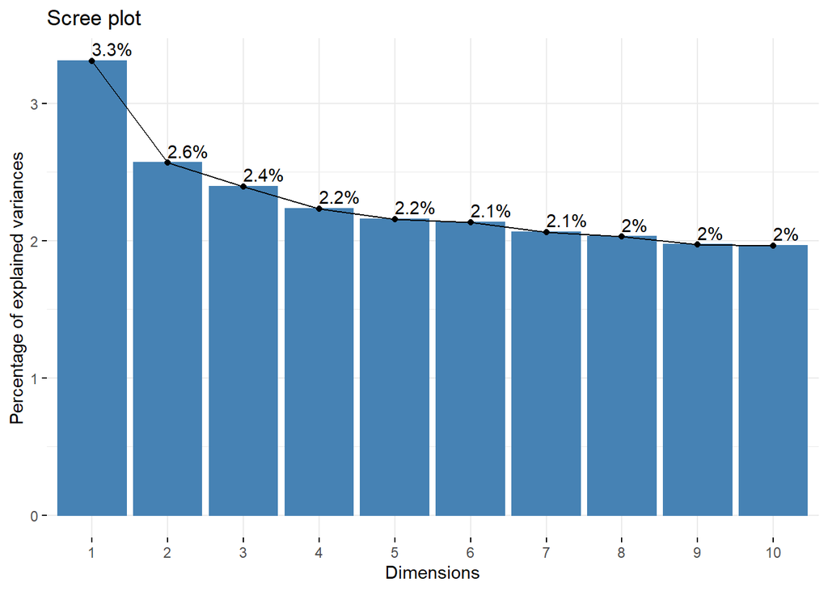

The variables only explain 20% of the variance within the data with the first 2 dimensions explaining 6%. The remainder of this analysis is based on these two dimensions.

The following two plot shows the correlation of variables against each dimension and the distribution of cases in these dimensions.

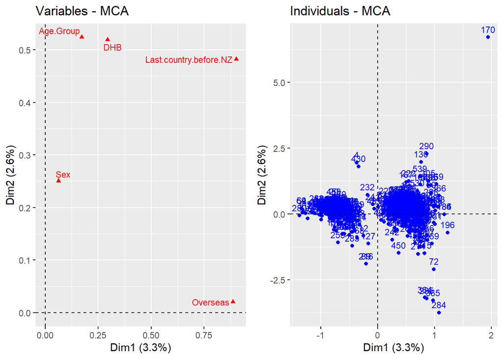

The analysis indicates the existence of three clusters and one outlier (Labelled 170).

The following analysis indicates that the two large clusters relate to people who travelled overseas (right hand side) and those who did not (those on the left). The right hand side is also influenced by cases in their 20s and over 50. The left hand side is heavily correlated to cases under 20 years.

Bay of Plenty, Tarawhiti, Whanganui and Lakes DHB are most highly correlated to the overseas group while Southern DHB is correlated to the local group.

The smaller cluster mainly relates to cases in Hawkes Bay from Spain, North America and Cambodia.

The outlier relates to a case reported in Taranaki but Gender and Age are unknown.

The following plots show the distribution of variables in each dimension.

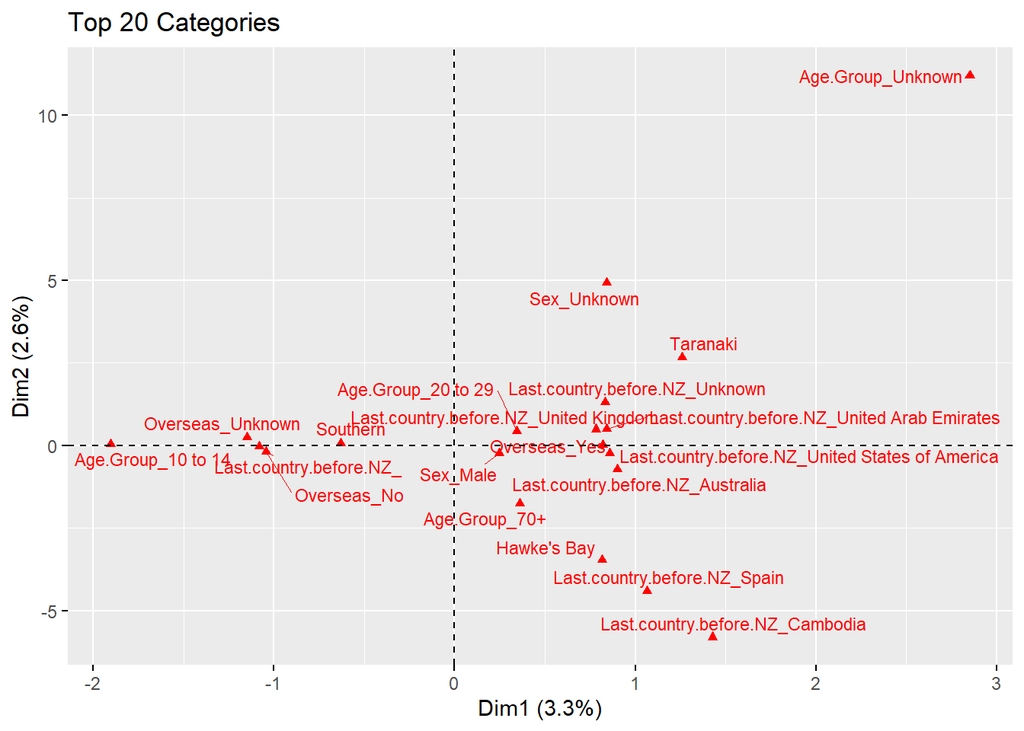

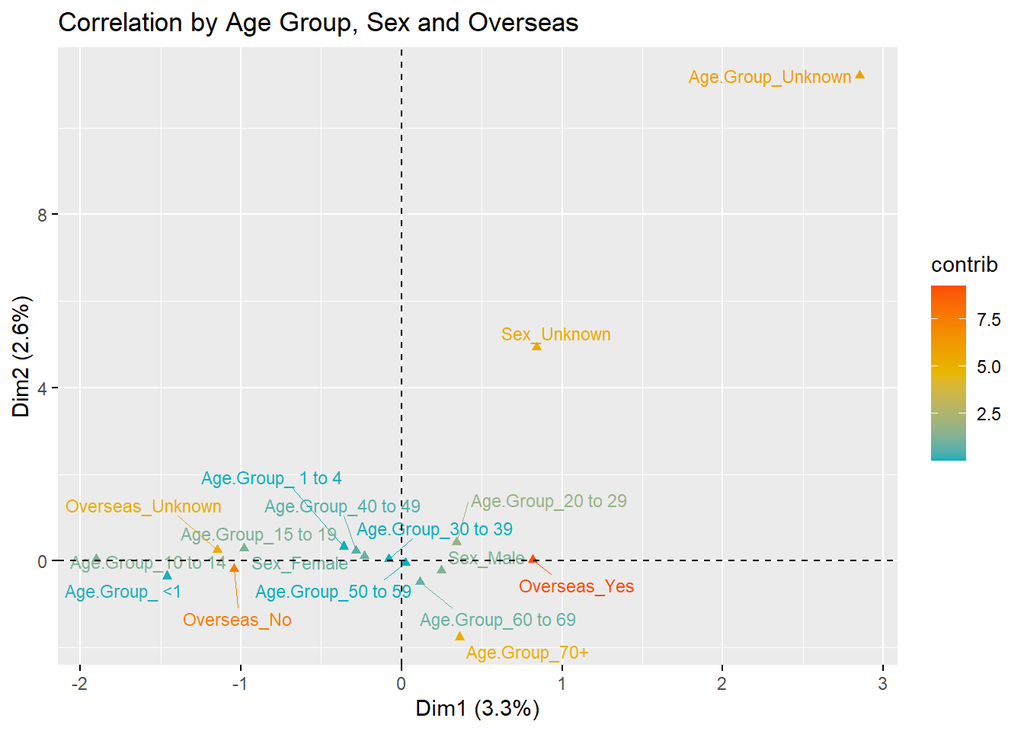

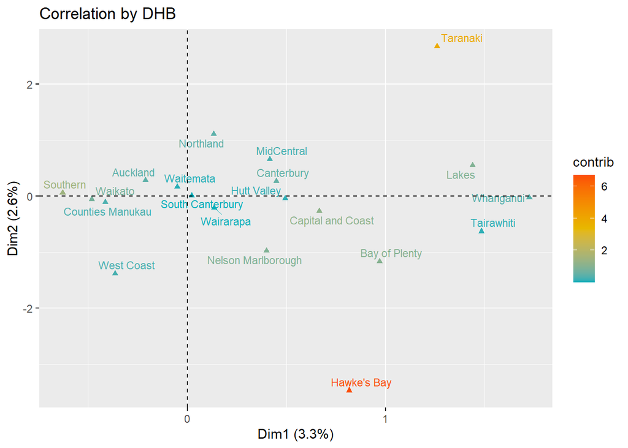

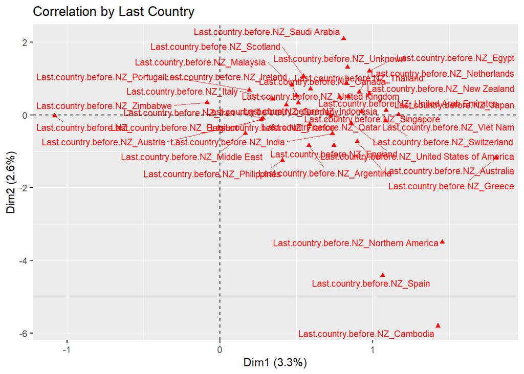

Finally, the following plots show the contribution of variables among each dimension.

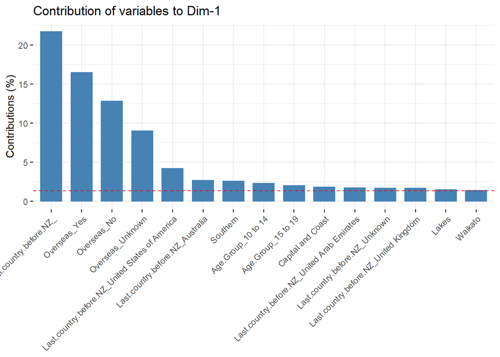

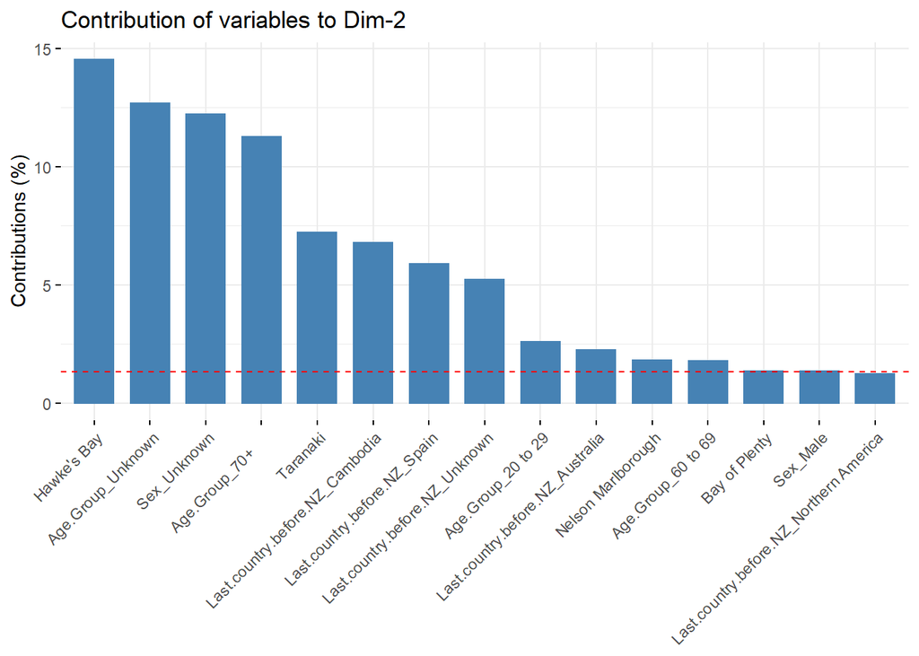

$~$

#### 3.2. Heirarchical Clustering

Hierarchical clustering aims to build a hierarchy of clusters. We use an Agglomerative algorithmic/bottom-up approach with each observation starting in its own cluster, and pairs of clusters are merged as one moves up the hierarchy.

The following dendogram shows the grouping of individual cases.

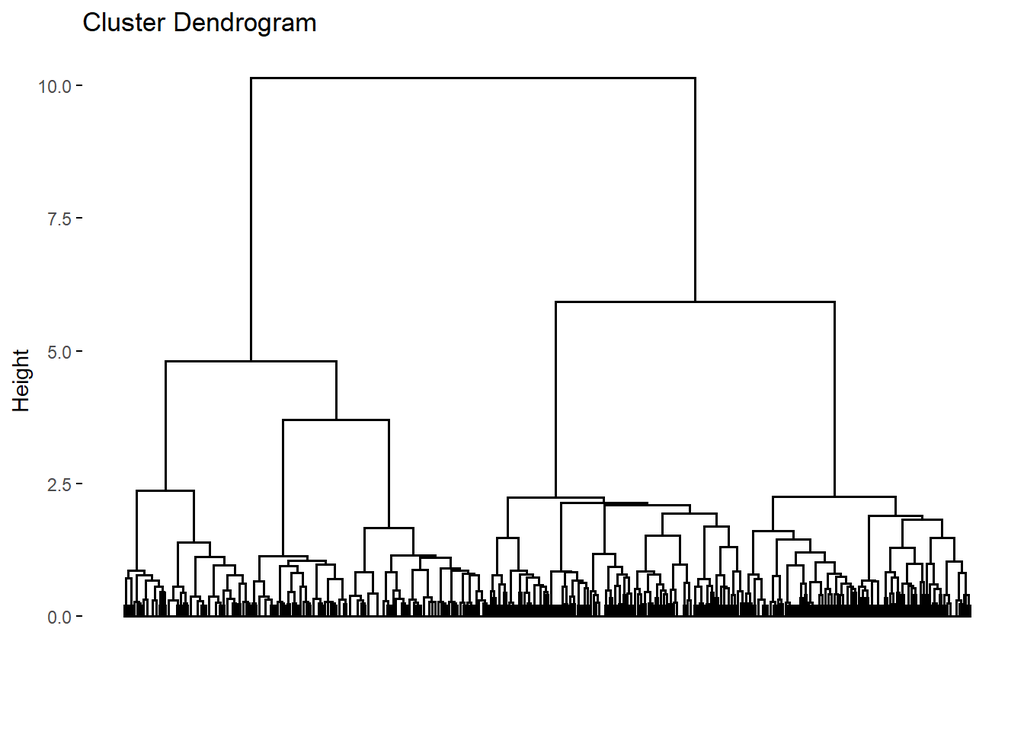

- All cases in Group 1 are from overseas
- Group 2 comprises of cases where it is unknown if the cases were from overseas.
- Group 3 comprises of females who did not travel overseas.
- Group 4 comprises of females who travelled overseas.
- Group 5 comprises of males who did not travel overseas.

$~$

#### 3.3. Hierarchical Clustering on Principal Components

The HCPC (Hierarchical Clustering on Principal Components) approach allows us to combine MCA, Hierarchical clustering and partitioning clustering (k-means).

The plots below shows that the optimal number of clusters is four. These are consistent with the results of the MCA.

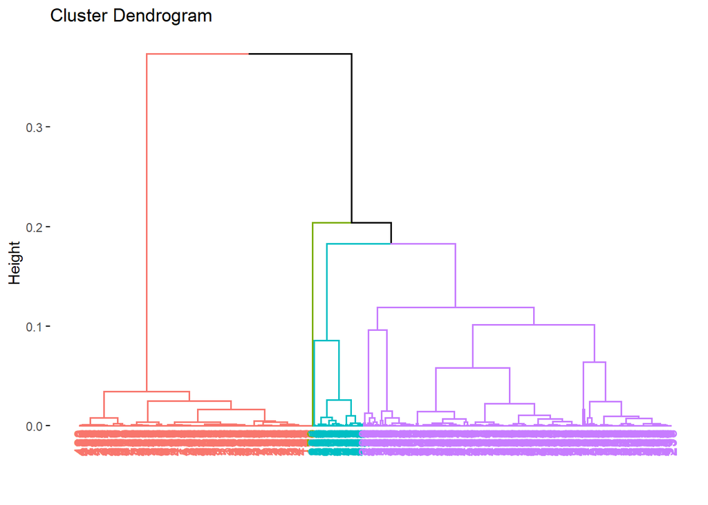

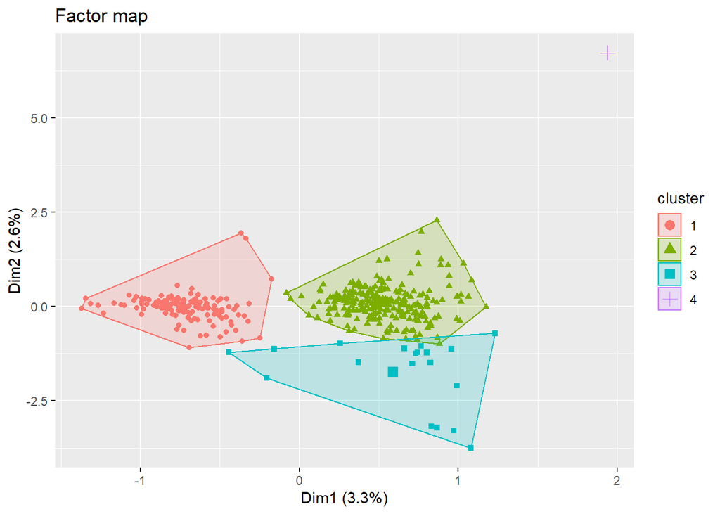

The table below shows the number of cases per cluster.

| Var1 | Freq |
| --- | --- |
| 1 | 234 |
| 2 | 297 |
| 3 | 20 |
| 4 | 1 |

The following outputs show some key attributes of each cluster as follows:

**Cluster 1**

- Comprises of 234 cases.
- 97% of cases that did not travel overseas belong to the cluster.
- All cases where it is unknown whether the individual travelled overseas belongs to the cluster.
- 66% of cases reported to Southern DHB and 58% of cases reported to Waikato DHB belong to this cluster.
- 61% of cases in the cluster are females.

Typical (paragon cases for this group include):

| Sex | Age.Group | DHB | Overseas | Last.country.before.NZ |
| --- | --- | --- | --- | --- |
| Female | 60 to 69 | Auckland | No |  |
| Female | 60 to 69 | Auckland | No |  |
| Female | 50 to 59 | Auckland | No |  |
| Female | 50 to 59 | Auckland | No |  |
| Female | 50 to 59 | Auckland | No |  |

**Cluster 2**

- Comprises of 297 cases.
- All cases in the cluster travelled overseas.
- 67% pf cases between ages of 20 and 29 belong to the cluster.
- 76% of cases in Capital & Coast, 92% of cases in Lakes and 70% of cases in Canterbury belong to the cluster.

Typical (paragon cases for this group include):

| Sex | Age.Group | DHB | Overseas | Last.country.before.NZ |
| --- | --- | --- | --- | --- |
| Male | 60 to 69 | Waikato | Yes | United Arab Emirates |
| Male | 30 to 39 | Waikato | Yes | United Arab Emirates |
| Female | 40 to 49 | Hutt Valley | Yes | United Arab Emirates |
| Male | 30 to 39 | Auckland | Yes | United Arab Emirates |
| Male | 40 to 49 | Waikato | Yes | United Arab Emirates |

**Cluster 3**

Typical (paragon cases for this group include):

| Sex | Age.Group | DHB | Overseas | Last.country.before.NZ |
| --- | --- | --- | --- | --- |
| Female | 20 to 29 | Hawke’s Bay | Yes | England |
| Female | 60 to 69 | Hawke’s Bay | Yes | Australia |
| Female | 50 to 59 | Counties Manukau | Yes | Spain |
| Male | 30 to 39 | Hawke’s Bay | Yes | Qatar |
| Male | 70+ | Hawke’s Bay | No |  |

**Cluster 4**

- Comprises of 1 case reported by Taranaki DHB who had travelled overseas. Not much is known about this case.

$-$

#### 3.4. K-Modes Clustering

K-modes uses dissimilarities and modes to identify clusters. A mode is a vector of elements that minimizes the dissimilarities between the vector itself and each object of the data.

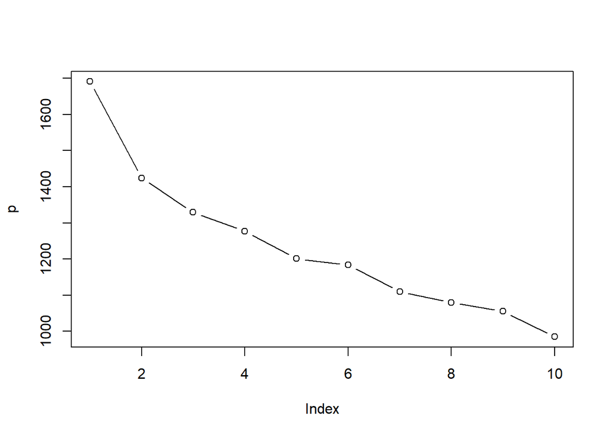

Size of Clusters

| cluster | Freq |
| --- | --- |
| 1 | 240 |
| 2 | 216 |
| 3 | 96 |

Mode of Clusters

|  | Sex | Age.Group | DHB | Overseas | Last.country.before.NZ |
| --- | --- | --- | --- | --- | --- |
| 1 | Male | 20 to 29 | Waikato | Yes | Australia |
| 2 | Female | 40 to 49 | Southern | No |  |
| 3 | Male | 30 to 39 | Auckland | Yes | United States of America |

$~$

#### 3.5. Factor Analysis

We conclude our analysis by extending the dataset with the derived variable “Duration” representing the number of days between date confirmed and date arrived in NZ.

Multiple factor analysis (MFA) is a multivariate data analysis method for summarizing and visualizing a complex data table in which individuals are described by several sets of variables (quantitative and /or qualitative) structured into groups.

The results are not presented below however this also delivered the same clusters as the MCA.

$-$

### 4. Conclussion

The above analysis illustrates a number of different trends within the key variables associated with confirmed COVID-19 cases in New Zealand.

New Zealand recorded their first confirmed case on the 26th of February and went into a complete four-week (Level 4) lockdown on the 26th of March.

In the next phase of this project, we will extend the results to show the impact of these measures.

We hope that our results are of value to some of our readers.

$-$

### 5. Acknowledgement

- We would like to acknowledge Mat Pawley and Teo Susnjak of Massey University
- We also acknowledge the various websites and forums that provide valuable information relating to these analysis techniques. In particular, we greatly appreciate the work of sthda.com and datanovia.com.

Finally, thank you to Nadira and Anayah for your love, support and patience.